# PS270 Final Project

My final project

Syver Gulbrandsen

## Project thoughts

A few areas which I am interested in exploring involve local elections, maybe something on the advertising aspect in elections or on economic downturns and how those effect elections. I switched my original interest from economic downturns and how those effect elections to a countries development and their taxes. I could not find a data set that matched what I wanted to accomplish for my first interest and then I came across this data set and found it pretty interesting.

```r
library(tidyverse)
data<-read_csv("data/govrev_v3.csv")
head(data)
```

```
# A tibble: 6 × 16
  cname   year ccode ccodecow ccodewb gdpnom   gdp centaxgdp centaxtot
  <chr>  <dbl> <dbl>    <dbl> <chr>    <dbl> <dbl>     <dbl>     <dbl>
1 Argen…  1800    32      160 ARG         NA    NA        NA        NA
2 Argen…  1801    32      160 ARG         NA    NA        NA        NA
3 Argen…  1802    32      160 ARG         NA    NA        NA        NA
4 Argen…  1803    32      160 ARG         NA    NA        NA        NA
5 Argen…  1804    32      160 ARG         NA    NA        NA        NA
6 Argen…  1805    32      160 ARG         NA    NA        NA        NA
# ℹ 7 more variables: centaxdirectsh <dbl>, centaxincomesh <dbl>,
#   centaxpropertysh <dbl>, centaxindirectsh <dbl>,
#   centaxcustomssh <dbl>, centaxexcisesh <dbl>, centaxconssh <dbl>
```

## Hypothesis/Research Question

My data set that I am using is from Per F. Anderson and is titled “Financing the State: Government Tax Revenue from 1800 to 2024”.It has information on the size and composition of government tax revenue from 31 countries between 1800 and 2024. My research question that I hope to answer using this data is “Do wealthier countries rely more on direct taxes rather than indirect taxes compared to poorer countries?” My hypothesis is that as countries get wealthier (as real gdp increases), they rely more on direct taxes vs indirect since the more developed they are, the better their institutions in place are and the better able they are to monitor and collect taxes on things like income efficiently. Poorer countries, may rely on indirect taxes more which are easier to collect. The explanatory variable would be gdp measuring total economic output. My outcome variable will be centaxdirectsh, which is direct tax revenue’s share out of total tax revenue. I would also like to see how another variable centaxindirectsh which is the indirect tax revenue’s share out of total tax revenue. The pattern that would prove my thesis, is that as a country develops over time, the centaxdirectsh increases along with GDP, so as countries get more developed they rely more on direct taxes, vs as countries who are less developed rely more on indirect taxes.

## Data Visualisation

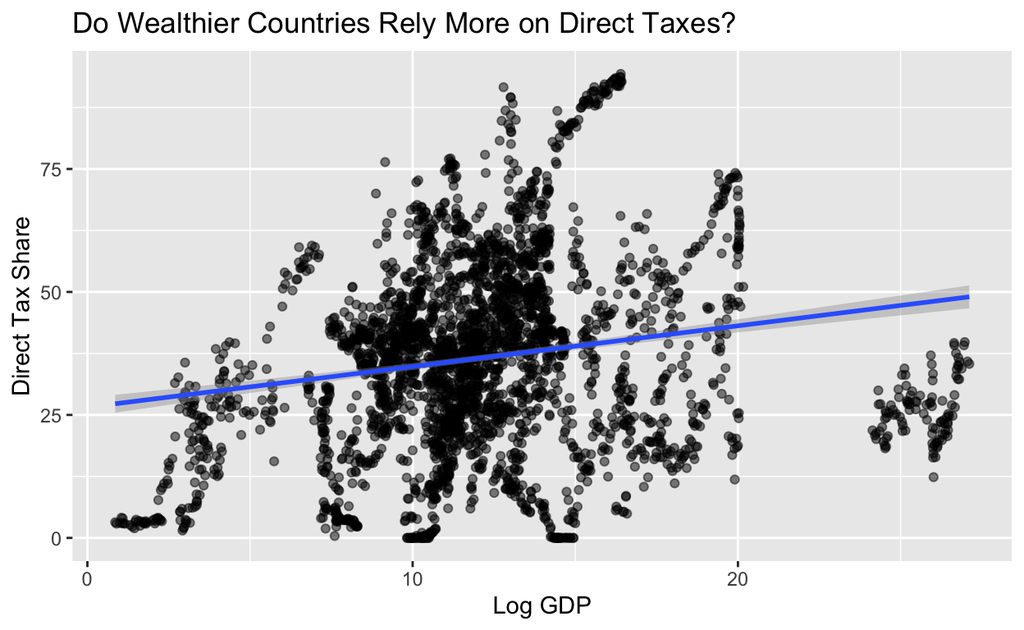

```r
data |>
  drop_na(gdp, centaxdirectsh) |>
  ggplot(aes(x = log(gdp), y = centaxdirectsh)) +
  geom_point(alpha = .5) +
  geom_smooth(method = "lm") +
  labs(
    x = "Log GDP",
    y = "Direct Tax Share",
    title = "Do Wealthier Countries Rely More on Direct Taxes?"
  )
```

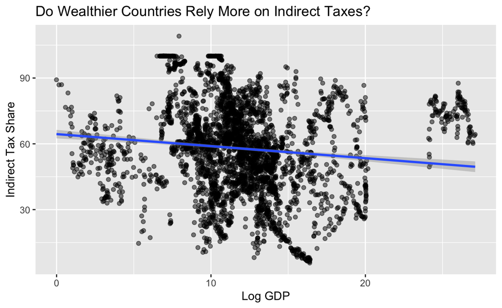

```r
data |>
  drop_na(gdp, centaxindirectsh) |>
  ggplot(aes(x = log(gdp), y = centaxindirectsh)) +
  geom_point(alpha = .5) +
  geom_smooth(method = "lm") +
  labs(
    x = "Log GDP",
    y = "Indirect Tax Share",
    title = "Do Wealthier Countries Rely More on Indirect Taxes?"
  )
```

## Interpretation

Both of these figures help illustrate how tax structure changes with economic development. The first graph shows a slight positive relationship between GDP and the share of revenue from direct taxes, suggesting that as a country gets wealthier they tend to rely somewhat more on direct taxation. The second graph shows the opposite for indirect taxes with a slight negative relationship between GDP and the indirect tax share. However, both plots have a lot of variation in how countries rely on the different types of reliance on taxes, indicating that the relationship is not very strong.